# Tidycensus will convince you to learn R

nicar.r-journalism.com/2025/

Andrew Ba Tran @abtran

2025-03-07

## Workshop agenda

- nicar.r-journalism.com/2025/ (Follow along here)
- Survey: https://bit.ly/3T6LkQh
- Intro to Tidycensus and RStudio
- Wrangling Census data with Tidyverse functions
- Common Census queries
- Visualizing Census data (if there’s time)

# The American Community Survey, R, and tidycensus

## What is the ACS?

- Annual survey of 3.5 million US households
- Covers more specific topics not available in **decennial** US Census data (e.g. income, education, language, housing characteristics)
- Available as 1-year estimates (for geographies of population 65,000 and greater) and 5-year estimates (for geographies down to the block group)
- Data delivered as *estimates* characterized by *margins of error*

## How to get ACS data

- data.census.gov is the main, revamped interactive data portal for browsing and downloading Census datasets, including the ACS
- censusreporter.org is a great resource (built by news nerds) and probably a lot of inspiration for the official census website revamp
- [The US Census **A**pplication **P**rogramming **I**nterface (API)](https://www.census.gov/data/developers/data-sets.html) allows developers to access Census data resources programmatically

## tidycensus

- R interface to the Decennial Census, American Community Survey, Population Estimates Program, and Public Use Microdata Series APIs
- First released in 2017; nearly 500,000 downloads from the Posit CRAN mirror
- [censusapi](https://www.hrecht.com/censusapi/) by data journalist Hannah Recht
  - Seeks to be an API wrapper for ALL Census products

[figure not shown]

By [Kyle Walker](https://walker-data.com/)

## Census data issues I

- Groups, sub groups, sub sub groups, etc, are a pain
- Takes forever to tidy up

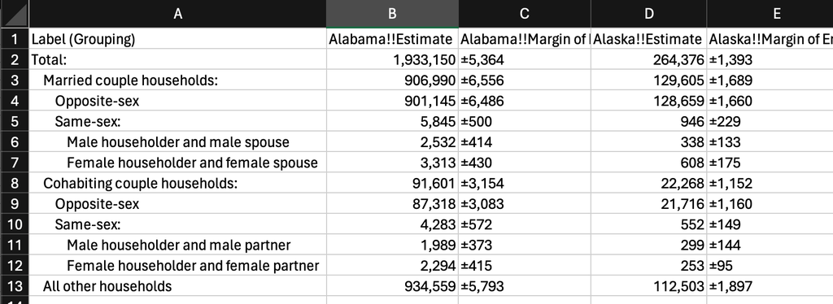

## Census data issues II

- Transposing the data helps a bit but
- Still requires a lot of work to clean up

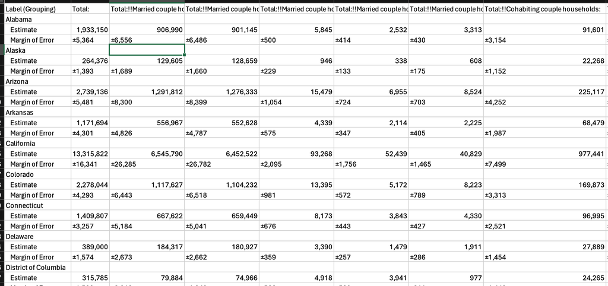

## Tidycensus: Features

- Wrangles Census data internally to return tidyverse-ready format (or traditional wide format if requested)
- Automatically downloads and merges Census geometries to data for **mapping**
- Includes tools for handling margins of error in the ACS and working with survey weights in the ACS PUMS
- States and counties can be requested by name (no more looking up FIPS codes!)
- Script out your process for re usability

## R and RStudio

- R: programming language and software environment for data analysis (and scraping and visualization and so much more)
- RStudio: integrated development environment (IDE) for R developed by **Posit**
  - Built on top of R
  - Lets you view your data, write and save R (or Python) scripts or notebooks, and view graphical static and interactive outputs

## RStudio tour

[figure not shown]

## Running code in R

- `<-` assignment saves to the environment/memory
- `#` hashes, commented out code
  - Copy and paste code into the console to run (without the hash)
- run code in the console at the bottom or
- in a script, highlight the code and click the ‘run’ button at the top right
- or put your cursor in the script on the line of code and hit ctrl+enter (or cmd + enter)

## Getting started with tidycensus

- To get started, install the packages and files for this class
- If you are using an IRE laptop, these packages are already installed for you

```r
install.packages(c("tidycensus", "tidyverse", "mapview", "usethis"))
usethis::use_course("https://github.com/r-journalism/nicar-2025-tidycensus/archive/master.zip")
```

## Optional: your Census API key

- tidycensus (and the Census API) can be used without an API key, but you will be limited to 500 queries per day
- Power users: visit https://api.census.gov/data/key_signup.html to request a key, then activate the key from the link in your email.
- Once activated, use the `census_api_key()` function to set your key as an environment variable

```r
library(tidycensus)

census_api_key("YOUR KEY GOES HERE", install = TRUE)
```